# Laboratorio 7: Regla de Taylor - Parte 1: Obtención de datos y análisis de las series de tiempo

Tasa de fondos federales, brecha del producto e inflación en EE. UU., 1970-1993

Araceli Martínez Holguín

20/10/2026

# 1 Objetivo:

Este laboratorio tiene dos partes.

- **Parte 1 (este documento).** Descargamos, limpiamos y describimos las tres series de tiempo que entran en una regla de Taylor:
  1. la **tasa de fondos federales** (el instrumento de política, $i_t$),
  2. el **PIB real**, del cual extraemos la **brecha del producto** ($\tilde{y}_t$) con el filtro de Hodrick-Prescott (HP),
  3. el **deflactor del PIB**, con el cual calculamos la **inflación** ($\pi_t$).
- **Parte 2 (próxima sesión).** Estimaremos la regla de Taylor por MCO y estimaremos la tasa de interés real de equilibrio $r^*$:

$$i_t = \alpha + \beta_\pi \,\pi_t + \beta_y \,\tilde{y}_t + \varepsilon_t$$

La regla de Taylor (1993) en su versión de libro de texto es $i_t = r^* + \pi_t + 0.5(\pi_t - \pi^*) + 0.5\,\tilde{y}_t$, de modo que el intercepto de la regresión por MCO cumple $\alpha = r^* - (\beta_\pi - 1)\pi^*$. Usarás esta relación en la Parte 2.

> **Qué se espera de ti en este Laboratorio** Además de ejecutar el código, debes *interpretar* cada serie (tendencia, ciclos, puntos de giro, episodios históricos) y describir las *relaciones entre ellas* (qué variables se mueven juntas, cuáles adelantan o rezagan a otras, y por qué).

# 2 Preparación

## 2.1 Paquetes

Instálalos una sola vez (ejecuta en la consola, no al compilar el documento):

```r
install.packages(c("fredr", "bea.R", "dplyr", "tidyr", "ggplot2",
                   "scales", "zoo", "mFilter"))
```

```r
library(fredr)
library(bea.R)
library(dplyr)
library(tidyr)
library(ggplot2)
library(scales)
library(zoo)
library(mFilter)
```

## 2.2 Claves de API

Nunca pegues claves de API en código que compartas o subas (a GitHub, al aula virtual, etc.). Guárdalas como variables de entorno.

Ejecuta esto **una sola vez** en la consola y luego reinicia R:

```r
# usethis::edit_r_environ()   # abre ~/.Renviron; agrega estas dos líneas:
# FRED_API_KEY=tu_clave_fred
# BEA_API_KEY=tu_clave_bea
```

Obtén tus claves aquí: FRED https://fred.stlouisfed.org/docs/api/fred/v2/api_key.html y BEA https://apps.bea.gov/api/signup/.

```r
# Sys.getenv() recibe el NOMBRE de la variable, no la clave.
fred_key <- Sys.getenv("FRED_API_KEY") # Pega aquí tu clave entre comillas sin el Sys.getenv
bea_key  <- Sys.getenv("BEA_API_KEY") # Pega aquí tu clave entre comillas sin el Sys.getenv

# Detener el código con un mensaje claro si falta alguna clave
if (!nzchar(fred_key) || !nzchar(bea_key)) {
  stop("No se encontró la clave de API. Agrega FRED_API_KEY y BEA_API_KEY a tu .Renviron ",
       "(usethis::edit_r_environ()), guarda y REINICIA R. ",
       "Alternativa rápida solo para esta sesión: ",
       "Sys.setenv(FRED_API_KEY = '...', BEA_API_KEY = '...')")
}

fredr_set_key(fred_key)
```

## 2.3 Muestra y tema común de los gráficos

Todas las series usan la misma muestra para poder unirlas después. Nota que el período (1970-1993) cubre la desinflación de Volcker y el inicio de la era Greenspan, el contexto en el que Taylor (1993) propuso su regla.

```r
start_date <- as.Date("1970-01-01")
end_date   <- as.Date("1993-12-31")

# Un solo tema para todas las figuras (evita repetir el mismo código)
theme_lab <- function() {
  theme_minimal(base_size = 12) +
    theme(
      plot.title         = element_text(hjust = 0.5, face = "bold"),
      plot.subtitle      = element_text(hjust = 0.5, color = "grey30"),
      plot.caption       = element_text(color = "grey40", size = 9),
      plot.background    = element_rect(fill = "white", color = NA),
      panel.background   = element_rect(fill = "white", color = NA),
      panel.grid.major.x = element_blank(),
      panel.grid.minor   = element_blank(),
      panel.grid.major.y = element_line(color = "grey90", linewidth = 0.3),
      axis.line.x        = element_line(color = "black", linewidth = 0.6),
      axis.ticks.x       = element_line(color = "black", linewidth = 0.4),
      axis.ticks.length  = unit(3, "pt"),
      legend.position    = "bottom"
    )
}

x_years <- scale_x_date(
  breaks = breaks_width("1 year"),
  labels = label_date("%Y"),
  expand = expansion(mult = c(0.01, 0.01))
)

dir.create("figures", showWarnings = FALSE)
```

# 3 El instrumento de política: la tasa de fondos federales

La tasa de fondos federales es la tasa de interés a la que los bancos se prestan reservas entre sí a un día. La Reserva Federal no la fija directamente, sino que la conduce hacia una meta mediante operaciones de mercado abierto. Es la variable del lado izquierdo, $i_t$, de la regla de Taylor.

Descargamos la tasa efectiva trimestral, para que tenga la misma frecuencia que el PIB.

```r
ff_q <- fredr(
  series_id          = "FEDFUNDS",
  observation_start  = start_date,
  observation_end    = end_date,
  frequency          = "q",
  aggregation_method = "avg"
)

head(ff_q)
```

| date | series_id | value | realtime_start | realtime_end |
| --- | --- | --- | --- | --- |
| 1970-01-01 | FEDFUNDS | 8.57 | 2026-10-13 | 2026-10-13 |
| 1970-04-01 | FEDFUNDS | 7.89 | 2026-10-13 | 2026-10-13 |
| 1970-07-01 | FEDFUNDS | 6.71 | 2026-10-13 | 2026-10-13 |
| 1970-10-01 | FEDFUNDS | 5.57 | 2026-10-13 | 2026-10-13 |
| 1971-01-01 | FEDFUNDS | 3.86 | 2026-10-13 | 2026-10-13 |
| 1971-04-01 | FEDFUNDS | 4.57 | 2026-10-13 | 2026-10-13 |

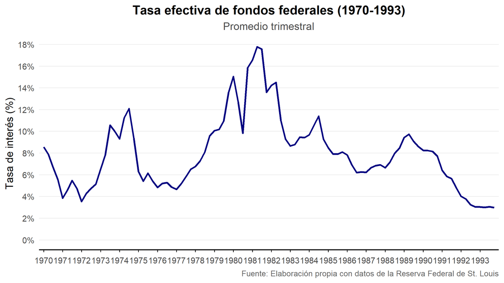

```r
p_ff <- ggplot(ff_q, aes(x = date, y = value)) +
  geom_line(color = "navy", linewidth = 1) +
  x_years +
  scale_y_continuous(labels = label_number(suffix = "%"),
                     breaks = breaks_width(2), limits = c(0, NA)) +
  labs(title    = "Tasa efectiva de fondos federales (1970-1993)",
       subtitle = "Promedio trimestral",
       x = NULL, y = "Tasa de interés (%)",
       caption  = "Fuente: Elaboración propia con datos de la Reserva Federal de St. Louis") +
  theme_lab()

print(p_ff)
```

```r
ggsave("figures/fed_funds_1970_1993.png", p_ff, width = 8, height = 4.5, dpi = 300, bg = "white")
```

```r
ff_q %>%
  summarise(mean = mean(value), sd = sd(value),
            max = max(value), date_max = date[which.max(value)],
            min = min(value), date_min = date[which.min(value)])
```

| mean | sd | max | date_max | min | date_min |
| --- | --- | --- | --- | --- | --- |
| 7.959792 | 3.339655 | 17.78 | 1981-04-01 | 2.99 | 1993-10-01 |

# 4 PIB real y brecha del producto

## 4.1 PIB real

El PIB real es el PIB medido a precios constantes (Precios de 2017), por lo que sus variaciones reflejan cantidades producidas y no cambios de precios. Usamos la Tabla 1.1.6 de las NIPA, serie `A191RX`.

```r
specs_gdp <- list(
  UserID       = bea_key,
  Method       = "GetData",
  DatasetName  = "NIPA",
  TableName    = "T10106",              # PIB real, dólares encadenados
  Frequency    = "Q",
  Year         = paste(1970:1993, collapse = ","),
  ResultFormat = "json"
)

gdp_raw <- beaGet(specs_gdp, asWide = FALSE)

# Si la solicitud falla, beaGet devuelve un mensaje de texto en lugar de un data frame
if (!is.data.frame(gdp_raw)) stop("Falló la solicitud a BEA: ", paste(gdp_raw, collapse = " "))

gdp <- gdp_raw %>%
  filter(SeriesCode == "A191RX") %>%
  transmute(
    date  = as.Date(as.yearqtr(TimePeriod, format = "%YQ%q")),
    value = as.numeric(DataValue)
  ) %>%
  arrange(date) %>%
  mutate(value_tn = value / 1e6)   # millones -> billones (10^12)

head(gdp)
```

| date | value | value_tn |
| --- | --- | --- |
| 1970-01-01 | 5300652 | 5.300652 |
| 1970-04-01 | 5308164 | 5.308164 |
| 1970-07-01 | 5357077 | 5.357077 |
| 1970-10-01 | 5299672 | 5.299672 |
| 1971-01-01 | 5443619 | 5.443619 |
| 1971-04-01 | 5473059 | 5.473059 |

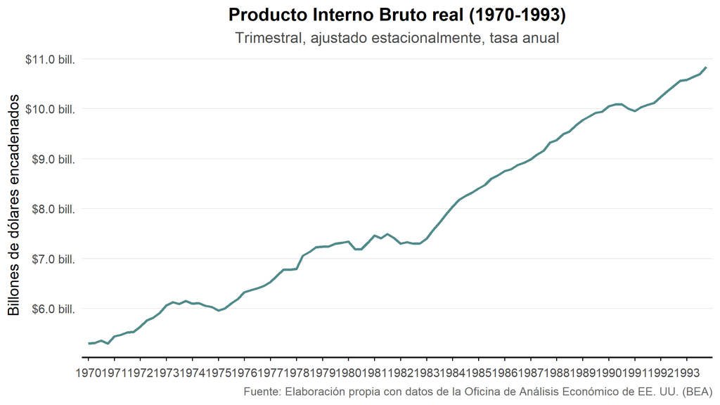

```r
p_gdp <- ggplot(gdp, aes(x = date, y = value_tn)) +
  geom_line(color = "#528B8B", linewidth = 1) +
  x_years +
  scale_y_continuous(labels = label_number(accuracy = 0.1, prefix = "$", suffix = " bill."),
                     breaks = breaks_pretty(n = 6)) +
  labs(title    = "Producto Interno Bruto real (1970-1993)",
       subtitle = "Trimestral, ajustado estacionalmente, tasa anual",
       x = NULL, y = "Billones de dólares encadenados",
       caption  = "Fuente: Elaboración propia con datos de la Oficina de Análisis Económico de EE. UU. (BEA)") +
  theme_lab()

print(p_gdp)
```

```r
ggsave("figures/real_gdp_1970_1993.png", p_gdp, width = 8, height = 4.5, dpi = 300, bg = "white")
```

## 4.2 Producto potencial y brecha del producto: el filtro HP

La regla de Taylor responde a la **brecha del producto**: la desviación porcentual del producto observado respecto del producto potencial. El producto potencial no se observa, por lo que debe estimarse. El filtro de Hodrick-Prescott (HP) descompone una serie $y_t$ (aquí, el $\log$ del PIB real) en una **tendencia** suave $\tau_t$ y un **ciclo** $c_t$, resolviendo

$$\min_{\{\tau_t\}} \; \sum_{t=1}^{T} (y_t - \tau_t)^2 \;+\; \lambda
\sum_{t=2}^{T-1} \big[(\tau_{t+1}-\tau_t)-(\tau_t-\tau_{t-1})\big]^2 .$$

El primer término penaliza la distancia respecto de los datos; el segundo penaliza los cambios en la *tasa de crecimiento* de la tendencia. El parámetro $\lambda$ controla esa disyuntiva: $\lambda = 1600$ es el valor estándar para datos **trimestrales**. Como usamos $\log y_t$, el ciclo multiplicado por 100 es la **brecha del producto en porcentaje**.

```r
gdp_ts <- ts(log(gdp$value), start = c(1970, 1), frequency = 4)
hp     <- hpfilter(gdp_ts, freq = 1600, type = "lambda")

gdp_hp <- gdp %>%
  mutate(
    trend    = as.numeric(hp$trend),
    cycle    = 100 * as.numeric(hp$cycle),   # desviación % respecto de la tendencia (brecha del producto)
    trend_tn = exp(trend) / 1e6
  )

head(gdp_hp)
```

| date | value | value_tn | trend | cycle | trend_tn |
| --- | --- | --- | --- | --- | --- |
| 1970-01-01 | 5300652 | 5.300652 | 15.47924 | 0.4101877 | 5.278954 |
| 1970-04-01 | 5308164 | 5.308164 | 15.48801 | -0.3248610 | 5.325436 |
| 1970-07-01 | 5357077 | 5.357077 | 15.49677 | -0.2845363 | 5.372342 |
| 1970-10-01 | 5299672 | 5.299672 | 15.50555 | -2.2391250 | 5.419677 |
| 1971-01-01 | 5443619 | 5.443619 | 15.51432 | -0.4366265 | 5.467439 |
| 1971-04-01 | 5473059 | 5.473059 | 15.52308 | -0.7733462 | 5.515549 |

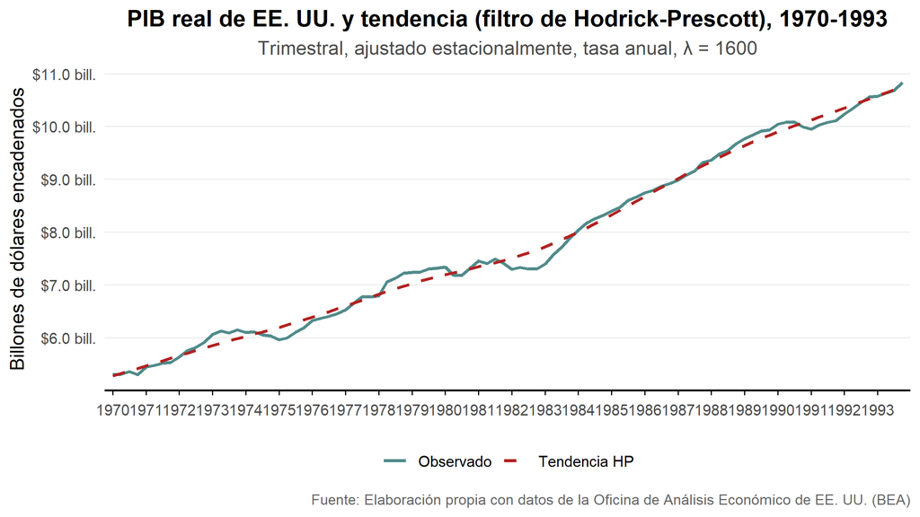

```r
p1 <- gdp_hp %>%
  select(date, Observado = value_tn, `Tendencia HP` = trend_tn) %>%
  pivot_longer(-date, names_to = "series", values_to = "value") %>%
  ggplot(aes(x = date, y = value, color = series, linetype = series)) +
  geom_line(linewidth = 1) +
  scale_color_manual(values = c("Observado" = "#528B8B", "Tendencia HP" = "firebrick")) +
  scale_linetype_manual(values = c("Observado" = "solid", "Tendencia HP" = "dashed")) +
  x_years +
  scale_y_continuous(labels = label_number(accuracy = 0.1, prefix = "$", suffix = " bill."),
                     breaks = breaks_pretty(n = 6)) +
  labs(title    = "PIB real de EE. UU. y tendencia (filtro de Hodrick-Prescott), 1970-1993",
       subtitle = "Trimestral, ajustado estacionalmente, tasa anual, \u03bb = 1600",
       x = NULL, y = "Billones de dólares encadenados", color = NULL, linetype = NULL,
       caption  = "Fuente: Elaboración propia con datos de la Oficina de Análisis Económico de EE. UU. (BEA)") +
  theme_lab()

print(p1)
```

```r
ggsave("figures/gdp_hp_trend.png", p1, width = 8, height = 4.5, dpi = 300, bg = "white")
```

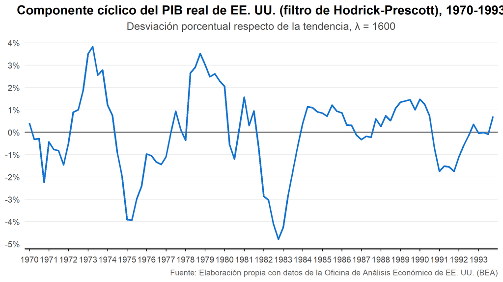

```r
p2 <- gdp_hp %>%
  ggplot(aes(x = date, y = cycle)) +
  geom_hline(yintercept = 0, color = "grey50", linewidth = 0.8) +
  geom_line(color = "#1874CD", linewidth = 1) +
  x_years +
  scale_y_continuous(labels = label_number(suffix = "%"), breaks = breaks_width(1)) +
  labs(title    = "Componente cíclico del PIB real de EE. UU. (filtro de Hodrick-Prescott), 1970-1993",
       subtitle = "Desviación porcentual respecto de la tendencia, \u03bb = 1600",
       x = NULL, y = NULL,
       caption  = "Fuente: Elaboración propia con datos de la Oficina de Análisis Económico de EE. UU. (BEA)") +
  theme_lab()

print(p2)
```

```r
ggsave("figures/gdp_hp_cycle.png", p2, width = 8, height = 4.5, dpi = 300, bg = "white")
```

```r
gdp_hp %>%
  summarise(mean_gap = mean(cycle), sd_gap = sd(cycle),
            max_gap = max(cycle), date_max = date[which.max(cycle)],
            min_gap = min(cycle), date_min = date[which.min(cycle)])
```

| mean_gap | sd_gap | max_gap | date_max | min_gap | date_min |
| --- | --- | --- | --- | --- | --- |
| -8.722745e-17 | 1.787137 | 3.826325 | 1973-04-01 | -4.787143 | 1982-10-01 |

# 5 Inflación: el deflactor del PIB

El **deflactor del PIB** es el cociente entre el PIB nominal y el PIB real (expresado como índice). Su tasa de crecimiento mide la inflación del conjunto de bienes y servicios producidos internamente. Usamos la Tabla 1.1.4 de las NIPA.

```r
specs_def <- list(
  UserID       = bea_key,
  Method       = "GetData",
  DatasetName  = "NIPA",
  TableName    = "T10104",             # Índices de precios del PIB
  Frequency    = "Q",
  Year         = paste(1970:1993, collapse = ","),
  ResultFormat = "json"
)

deflator_raw <- beaGet(specs_def, asWide = FALSE)
if (!is.data.frame(deflator_raw)) stop("Falló la solicitud a BEA: ", paste(deflator_raw, collapse = " "))

# Siempre revisa qué series trae la tabla antes de filtrar
deflator_raw %>% distinct(LineNumber, SeriesCode, LineDescription) %>% head()
```

| LineNumber | SeriesCode | LineDescription |
| --- | --- | --- |
| 1 | A191RG | Gross domestic product |
| 2 | DPCERG | Personal consumption expenditures |
| 3 | DGDSRG | Goods |
| 4 | DDURRG | Durable goods |
| 5 | DNDGRG | Nondurable goods |
| 6 | DSERRG | Services |

```r
deflator <- deflator_raw %>%
  filter(LineNumber == "1") %>%          # Línea 1 = Producto interno bruto
  transmute(
    date  = as.Date(as.yearqtr(TimePeriod, format = "%YQ%q")),
    value = as.numeric(DataValue)
  ) %>%
  arrange(date) %>%
  mutate(inflation = 100 * ((value / lag(value))^4 - 1))   # % de variación anualizado

head(deflator)
```

| date | value | inflation |
| --- | --- | --- |
| 1970-01-01 | 19.823 | NA |
| 1970-04-01 | 20.109 | 5.897174 |
| 1970-07-01 | 20.274 | 3.322730 |
| 1970-10-01 | 20.539 | 5.331777 |
| 1971-01-01 | 20.850 | 6.195731 |
| 1971-04-01 | 21.130 | 5.480882 |

**¿Por qué el exponente 4?** La variación trimestral se convierte en una *tasa anual* (lo que se obtendría si la inflación de ese trimestre se mantuviera durante todo un año). Es la misma convención que usa BEA para el crecimiento del PIB, y deja la inflación en las mismas unidades que la tasa de fondos federales (porcentaje anual). La primera observación es `NA` porque no tiene un trimestre previo.

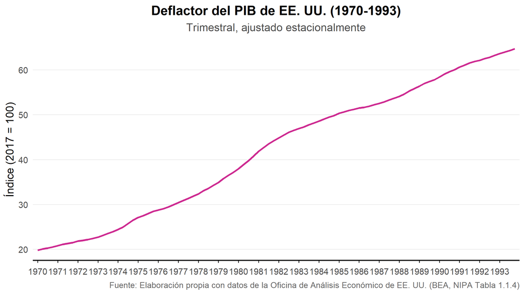

```r
p_def <- ggplot(deflator, aes(x = date, y = value)) +
  geom_line(color = "#CD2990", linewidth = 1) +
  x_years +
  scale_y_continuous(labels = label_number(accuracy = 1), breaks = breaks_pretty(n = 6)) +
  labs(title    = "Deflactor del PIB de EE. UU. (1970-1993)",
       subtitle = "Trimestral, ajustado estacionalmente",
       x = NULL, y = "Índice (2017 = 100)",
       caption  = "Fuente: Elaboración propia con datos de la Oficina de Análisis Económico de EE. UU. (BEA, NIPA Tabla 1.1.4)") +
  theme_lab()

print(p_def)
```

```r
ggsave("figures/gdp_deflator_1970_1993.png", p_def, width = 8, height = 4.5, dpi = 300, bg = "white")
```

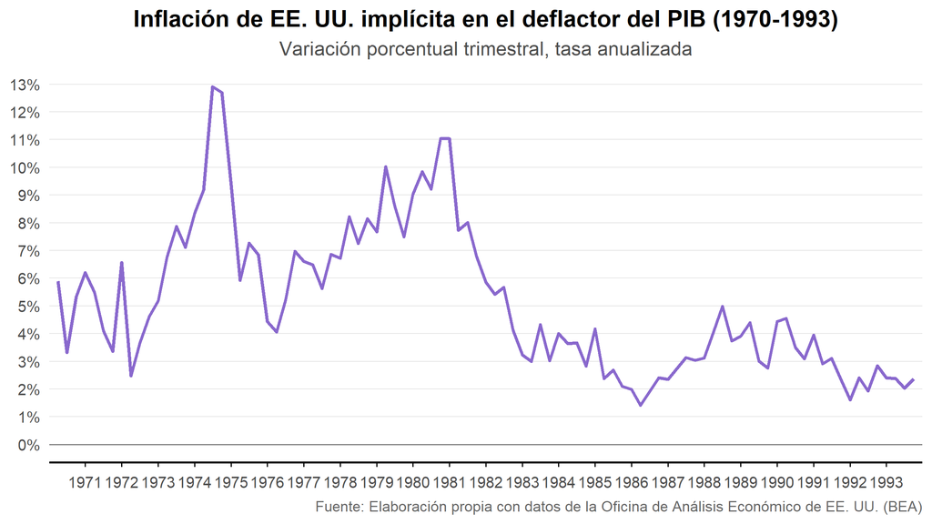

```r
p_infl <- deflator %>%
  filter(!is.na(inflation)) %>%
  ggplot(aes(x = date, y = inflation)) +
  geom_hline(yintercept = 0, color = "grey50", linewidth = 0.4) +
  geom_line(color = "#8968CD", linewidth = 1) +
  x_years +
  scale_y_continuous(labels = label_number(suffix = "%"), breaks = breaks_width(1)) +
  labs(title    = "Inflación de EE. UU. implícita en el deflactor del PIB (1970-1993)",
       subtitle = "Variación porcentual trimestral, tasa anualizada",
       x = NULL, y = NULL,
       caption  = "Fuente: Elaboración propia con datos de la Oficina de Análisis Económico de EE. UU. (BEA)") +
  theme_lab()

print(p_infl)
```

```r
ggsave("figures/gdp_deflator_inflation.png", p_infl, width = 8, height = 4.5, dpi = 300, bg = "white")
```

```r
deflator %>%
  filter(!is.na(inflation)) %>%
  mutate(period = case_when(
    date < as.Date("1983-01-01") ~ "1970-1982",
    date < as.Date("1987-01-01") ~ "1983-1986",
    TRUE                          ~ "1987-1993")) %>%
  group_by(period) %>%
  summarise(mean_inflation = mean(inflation), sd_inflation = sd(inflation))
```

| period | mean_inflation | sd_inflation |
| --- | --- | --- |
| 1970-1982 | 6.952798 | 2.3059576 |
| 1983-1986 | 2.921764 | 0.8699294 |
| 1987-1993 | 3.109886 | 0.8652375 |

# 6 Comparando las series

Esta sección es el núcleo de la Parte 1. Unimos las tres series trimestrales en una sola base de datos. Este es exactamente el data frame que usarás para la regresión en la Parte 2.

```r
taylor_data <- ff_q %>%
  select(date, ffr = value) %>%
  inner_join(gdp_hp  %>% select(date, gap = cycle),      by = "date") %>%
  inner_join(deflator %>% select(date, inflation),        by = "date") %>%
  filter(!is.na(inflation))

# ¿Cuántas observaciones perdemos y por qué?
nrow(taylor_data)
```

```
## [1] 95
```

```r
range(taylor_data$date)
```

```
## [1] "1970-04-01" "1993-10-01"
```

```r
summary(taylor_data)
```

```
##       date                 ffr              gap              inflation
##  Min.   :1970-04-01   Min.   : 2.990   Min.   :-4.787143   Min.   : 1.405
##  1st Qu.:1976-02-15   1st Qu.: 5.450   1st Qu.:-1.015313   1st Qu.: 3.011
##  Median :1982-01-01   Median : 7.820   Median : 0.120771   Median : 4.398
##  Mean   :1981-12-31   Mean   : 7.953   Mean   :-0.004318   Mean   : 5.141
##  3rd Qu.:1987-11-16   3rd Qu.: 9.520   3rd Qu.: 1.039774   3rd Qu.: 6.853
##  Max.   :1993-10-01   Max.   :17.780   Max.   : 3.826325   Max.   :12.907
```

## 6.1 Las tres series en un mismo gráfico

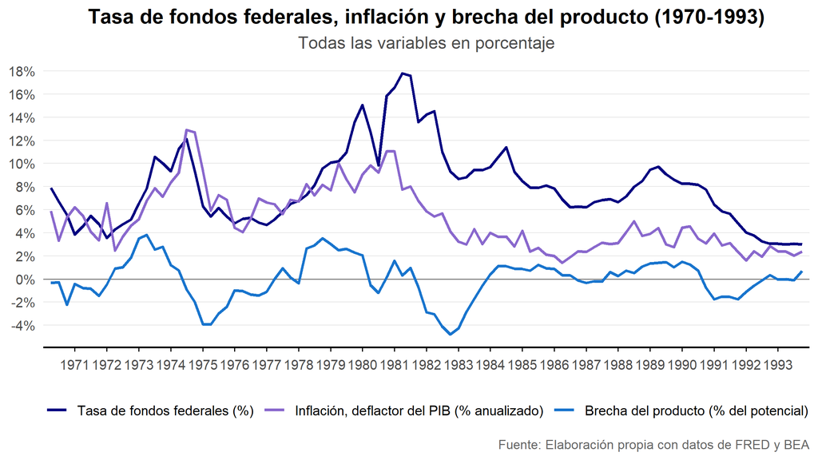

```r
p_all <- taylor_data %>%
  pivot_longer(-date, names_to = "variable", values_to = "value") %>%
  mutate(variable = factor(variable,
                           levels = c("ffr", "inflation", "gap"),
                           labels = c("Tasa de fondos federales (%)",
                                      "Inflación, deflactor del PIB (% anualizado)",
                                      "Brecha del producto (% del potencial)"))) %>%
  ggplot(aes(x = date, y = value, color = variable)) +
  geom_hline(yintercept = 0, color = "grey50", linewidth = 0.4) +
  geom_line(linewidth = 1) +
  scale_color_manual(values = c("navy", "#8968CD", "#1874CD")) +
  x_years +
  scale_y_continuous(labels = label_number(suffix = "%"), breaks = breaks_width(2)) +
  labs(title    = "Tasa de fondos federales, inflación y brecha del producto (1970-1993)",
       subtitle = "Todas las variables en porcentaje",
       x = NULL, y = NULL, color = NULL,
       caption  = "Fuente: Elaboración propia con datos de FRED y BEA") +
  theme_lab()

print(p_all)
```

```r
ggsave("figures/taylor_variables.png", p_all, width = 8, height = 4.5, dpi = 300, bg = "white")
```

## 6.2 Correlaciones y diagramas de dispersión

```r
cor(taylor_data[, c("ffr", "inflation", "gap")])
```

```
##                 ffr  inflation        gap
## ffr       1.0000000 0.53638516 0.16533126
## inflation 0.5363852 1.00000000 0.09656684
## gap       0.1653313 0.09656684 1.00000000
```

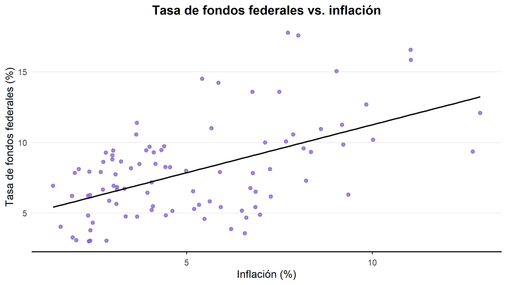

```r
p_sc1 <- ggplot(taylor_data, aes(x = inflation, y = ffr)) +
  geom_point(color = "#8968CD", alpha = 0.8) +
  geom_smooth(method = "lm", se = FALSE, color = "black", linewidth = 0.7) +
  labs(title = "Tasa de fondos federales vs. inflación",
       x = "Inflación (%)", y = "Tasa de fondos federales (%)") +
  theme_lab()

p_sc2 <- ggplot(taylor_data, aes(x = gap, y = ffr)) +
  geom_point(color = "#1874CD", alpha = 0.8) +
  geom_smooth(method = "lm", se = FALSE, color = "black", linewidth = 0.7) +
  labs(title = "Tasa de fondos federales vs. brecha del producto",
       x = "Brecha del producto (%)", y = "Tasa de fondos federales (%)") +
  theme_lab()

print(p_sc1)
```

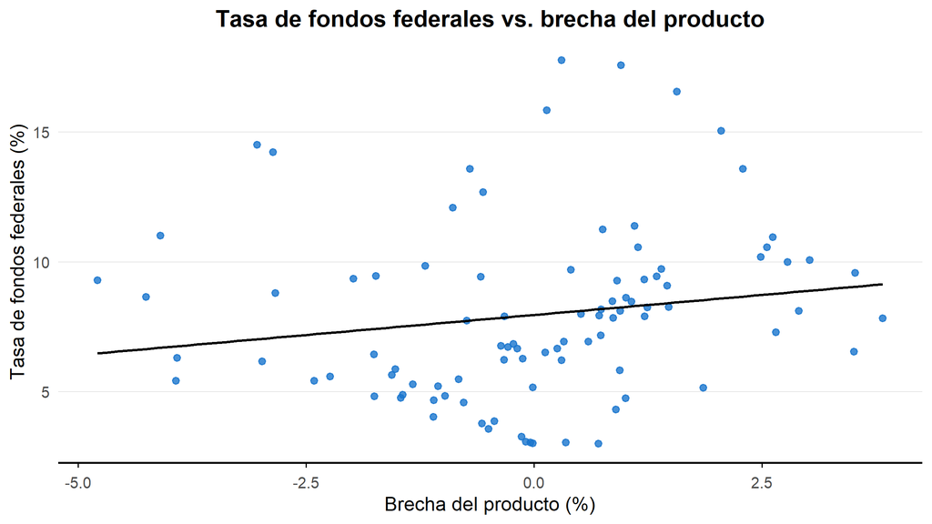

```r
print(p_sc2)
```

## 6.3 Adelantos y rezagos

La política monetaria afecta a la economía con rezago, y la Fed reacciona a información que llega con retraso. La función de correlación cruzada muestra la correlación entre $x_{t+k}$ e $y_t$ para distintos rezagos $k$.

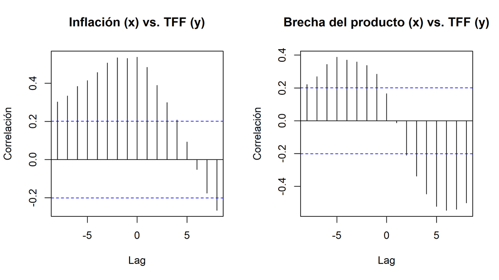

```r
par(mfrow = c(1, 2))
ccf(taylor_data$inflation, taylor_data$ffr, lag.max = 8,
    main = "Inflación (x) vs. TFF (y)", ylab = "Correlación")
ccf(taylor_data$gap, taylor_data$ffr, lag.max = 8,
    main = "Brecha del producto (x) vs. TFF (y)", ylab = "Correlación")
```

```r
par(mfrow = c(1, 1))
```

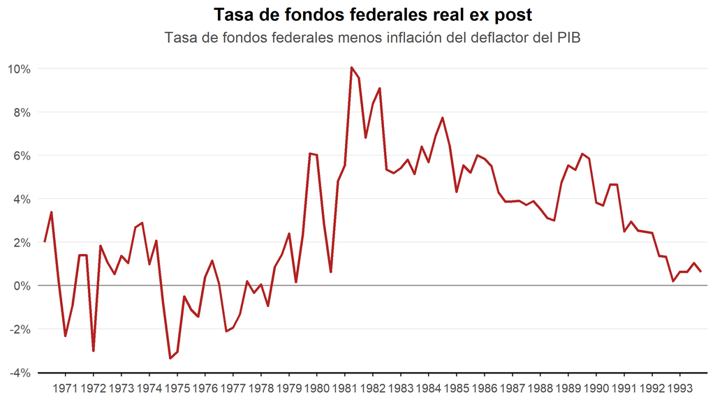

```r
taylor_data <- taylor_data %>% mutate(real_rate = ffr - inflation)

ggplot(taylor_data, aes(x = date, y = real_rate)) +
  geom_hline(yintercept = 0, color = "grey50", linewidth = 0.4) +
  geom_line(color = "firebrick", linewidth = 1) +
  x_years +
  scale_y_continuous(labels = label_number(suffix = "%"), breaks = breaks_width(2)) +
  labs(title = "Tasa de fondos federales real ex post",
       subtitle = "Tasa de fondos federales menos inflación del deflactor del PIB",
       x = NULL, y = NULL) +
  theme_lab()
```

```r
mean(taylor_data$real_rate)
```

```
## [1] 2.812129
```

```r
# Guardar la base unida para la Parte 2
saveRDS(taylor_data, "taylor_data.rds")
write.csv(taylor_data, "taylor_data.csv", row.names = FALSE)
```